## Background

This assignment makes use of data from a personal activity monitoring device. This device collects data at 5 minute intervals through out the day. The data consists of two months of data from an anonymous individual collected during the months of October and November, 2012 and include the number of steps taken in 5 minute intervals each day. The data has been analyzed to answer the following questions.

- What is the mean of the total number of steps taken each day.
- What is the average daily activity pattern
- What is the impact of imputing missing values in the data
- What is the difference in activity comparing weekdays and weekends.

## Mean Total Number of Steps taken per day

# Distribution of the total number of steps taken everyday.

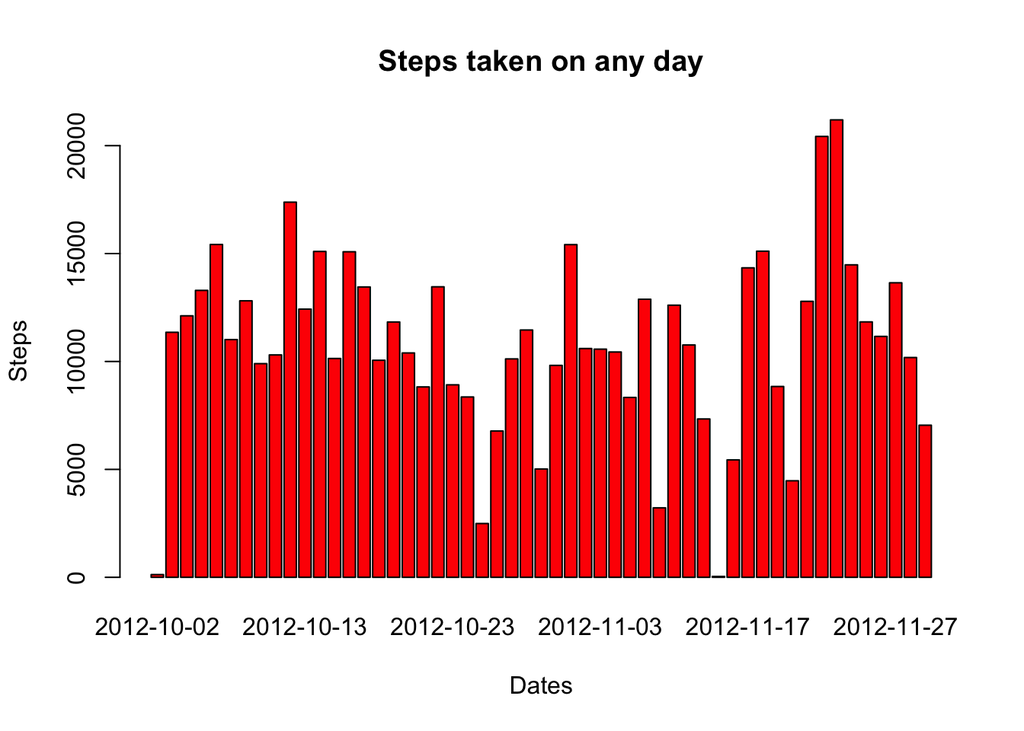

# Mean and median of the steps taken everyday.

```
##          date          x
##  2012-10-02: 1   Min.   :   41
##  2012-10-03: 1   1st Qu.: 8841
##  2012-10-04: 1   Median :10765
##  2012-10-05: 1   Mean   :10766
##  2012-10-06: 1   3rd Qu.:13294
##  2012-10-07: 1   Max.   :21194
##  (Other)   :47
```

## What is the average daily activity pattern?

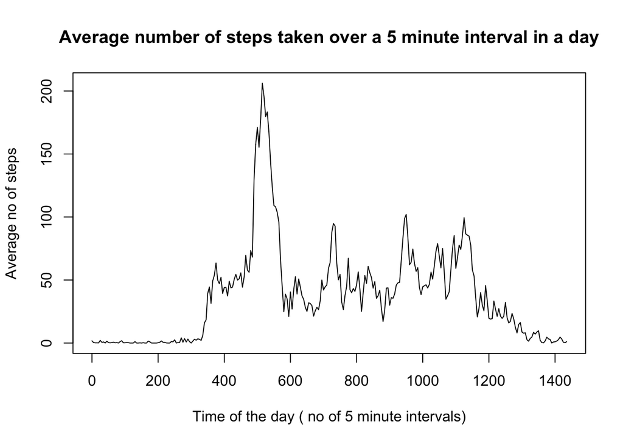

```
##     interval        x
## 104      835 206.1698
## 105      840 195.9245
## 107      850 183.3962
## 106      845 179.5660
## 103      830 177.3019
## 101      820 171.1509
```

The time interval around 515 minutes ( 8:35 AM ) has the highest number of steps.

## Imputing missing values

There are 2304 missing values in the dataset.

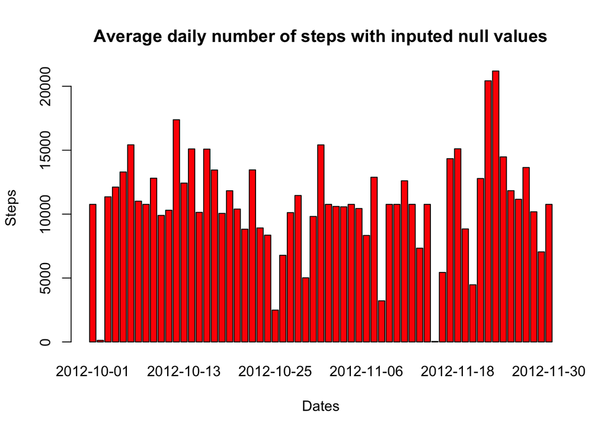

```
##          date          x
##  2012-10-01: 1   Min.   :   41
##  2012-10-02: 1   1st Qu.: 9819
##  2012-10-03: 1   Median :10762
##  2012-10-04: 1   Mean   :10766
##  2012-10-05: 1   3rd Qu.:12811
##  2012-10-06: 1   Max.   :21194
##  (Other)   :55
```

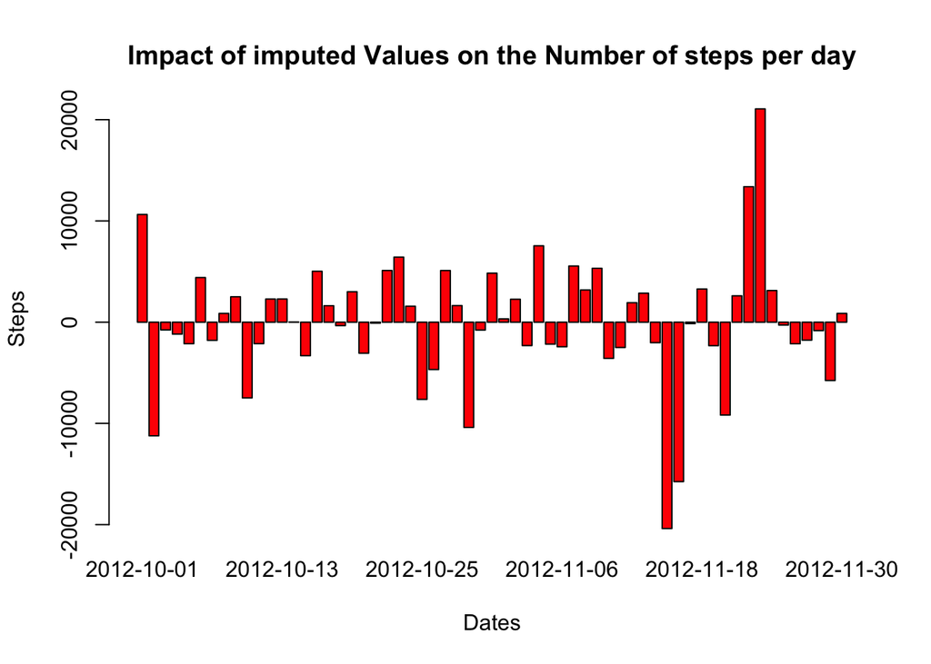

## Difference in activity Patterns between weekdays and weekends.

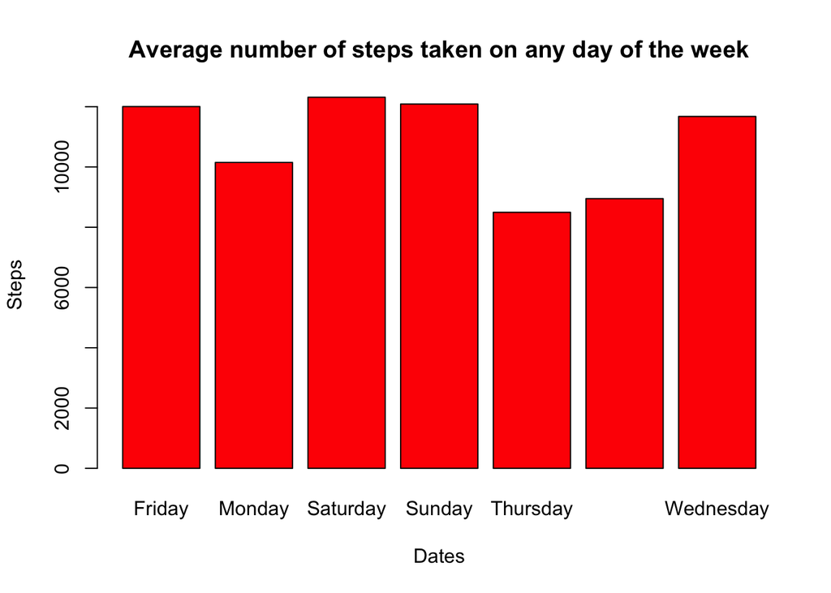

```
##         day         x
## 1    Friday 12004.667
## 2    Monday 10149.778
## 3  Saturday 12313.750
## 4    Sunday 12088.250
## 5  Thursday  8496.000
## 6   Tuesday  8949.556
## 7 Wednesday 11676.444
```

There is slightly more activity on weekends as compared to weekdays. 1946 additional steps were taken on weekends.